# Tytanis - analiza przeżycia

Michał rab

5 02 2022

# Wstęp

Niemal każdy z nas słyszał o katastrofie RMS Titanic - transatlantyckiego statku pasażerskiego typu Olympic. Przyczyną katastrofy było zderzenie się z górą lodową, w wyniku czego statek zatonął, a śmierć poniosło ok. 1500 osób (dane o ofiarach są niejednoznaczne).

# Cel analizy

Celem analizy jest sprawdzenie, jakie czynniki miały wpływ na przeżycie katastrofy.

# Analiza

Na początku wczytany zostanie plik z przygotowanymi wcześniej danymi

## Kto przeżył?

Na wstępie spróbujmy przyjrzeć się podstawowym danym. Zobaczmy, jakie dane dostępne są w zbiorze danych:

```
## 'data.frame':    717 obs. of  8 variables:
##  $ Survived: int  0 1 1 1 0 0 0 1 1 1 ...
##  $ Pclass  : int  3 1 3 1 3 1 3 3 2 3 ...
##  $ Sex     : chr  "male" "female" "female" "female" ...
##  $ Age     : int  22 38 26 35 35 54 2 27 14 4 ...
##  $ SibSp   : int  1 1 0 1 0 0 3 0 1 1 ...
##  $ Parch   : int  0 0 0 0 0 0 1 2 0 1 ...
##  $ Fare    : num  7.25 71.28 7.92 53.1 8.05 ...
##  $ Embarked: chr  "S" "C" "S" "S" ...
```

Zobaczmy, kto przeżył, na podstawie samej płci. Zliczone zostaną osoby (osobno kobiety i mężczyźni), które przeżyły, a następnie podzielone zostaną przez całkowitą liczbę osób (osobno kobiety i mężczyźni).

```
## [1] "Przeżywalność kobiet [%]: 0.76"
```

```
## [1] "Przeżywalność mężczyzn [%]:  0.21"
```

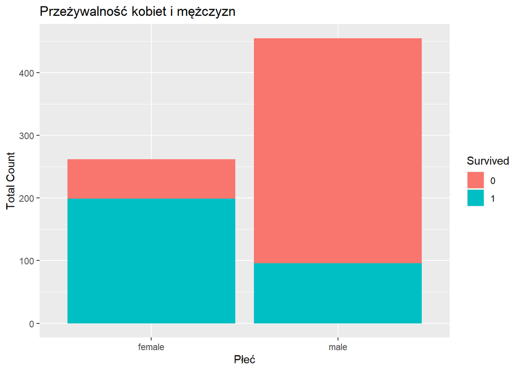

Jak widać, płeć ma bardzo duże znaczenie. Zobaczmy, jak wygląda przeżywalność z uwzględnieniem klasy.

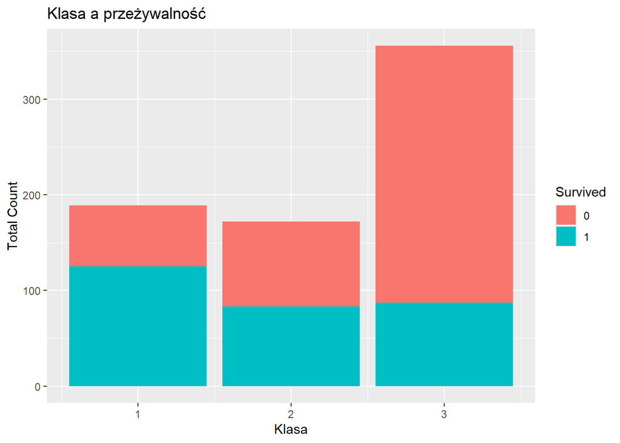

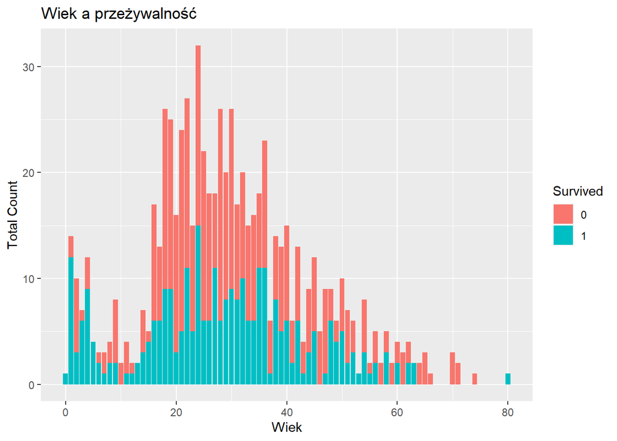

Wizualnie widać, że odsetek młodszych osób, które przeżyły, jest wyraźnie wyższy. Zobaczmy, jak prezentuje się przeżywalność z uwzględnieniem zarówno płci, wieku i klasy.

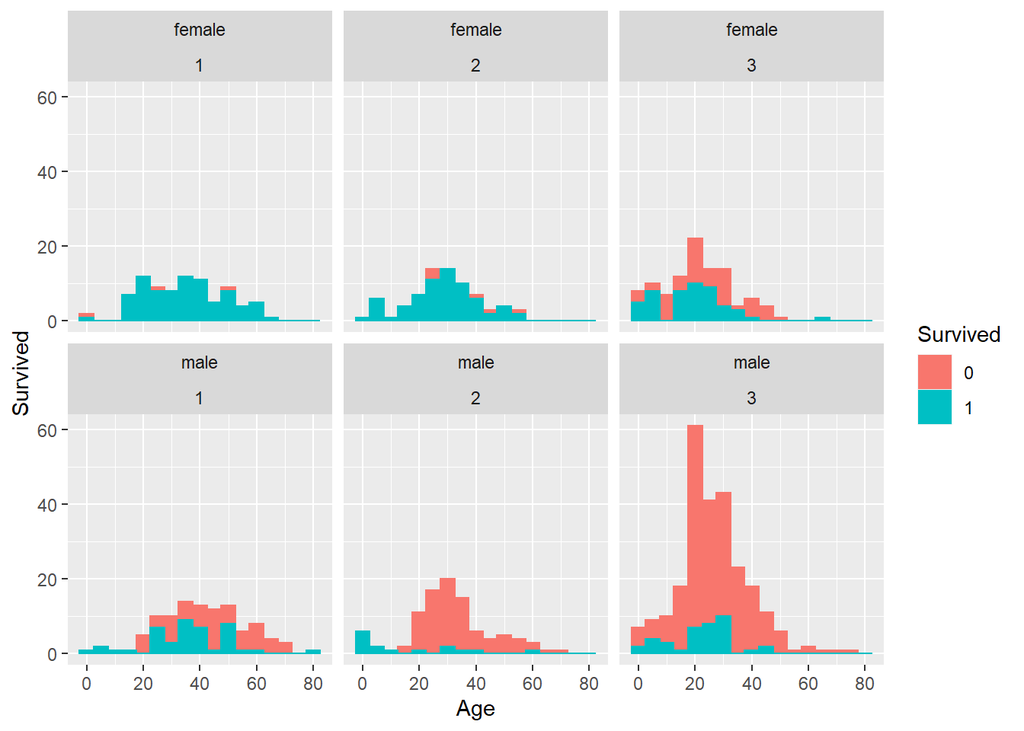

Zwróćmy uwagę na porównanie przeżywalności a portu, z którego wypłynęły dane osoby

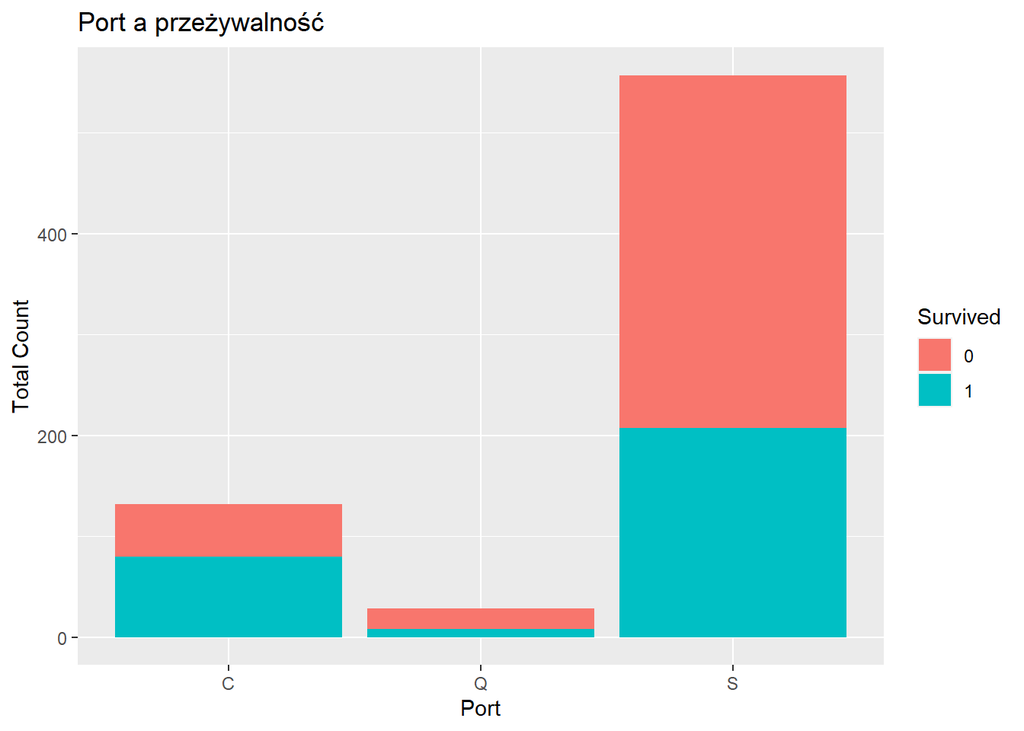

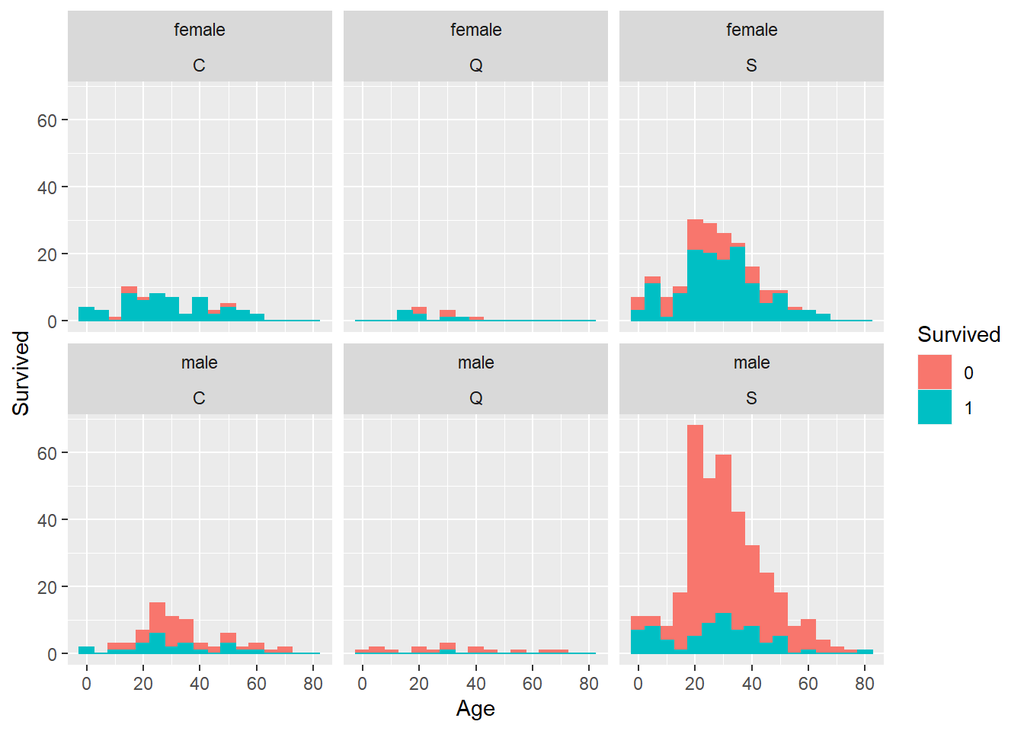

Zobaczmy jeszcze, jak wygląda przeżywalność w zależności od płci i portu

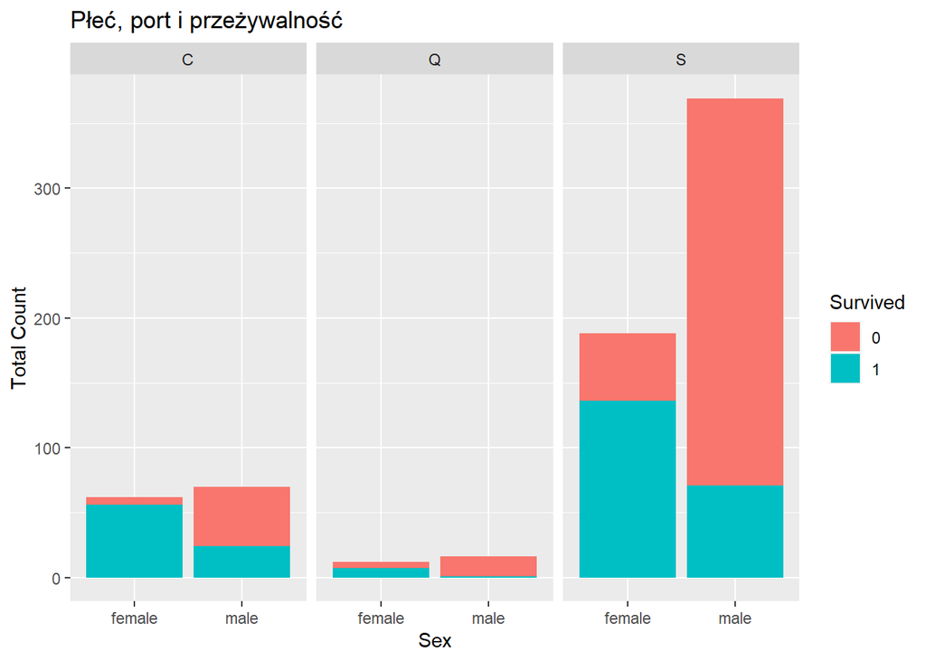

Wyraźnie widać, że osoby płynące z Queenstown i Southampton miały zdecydowanie niższą szansę na przeżycie względem osób płynących z Cherbourg. Zobaczmy, jak wyglądały klasy względem portów

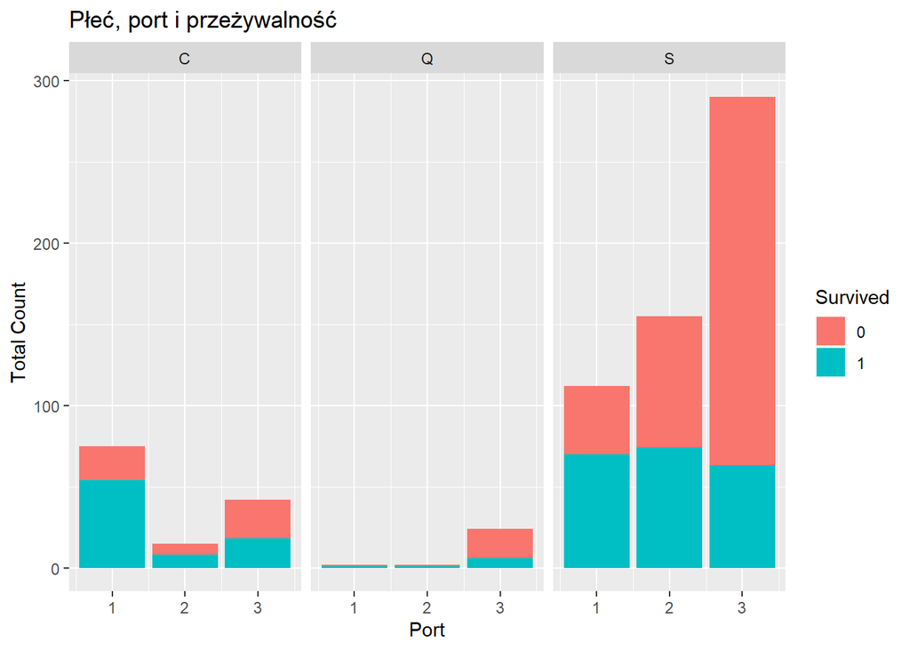

Zobaczmy, jaka jest przeżywalność dzieci:

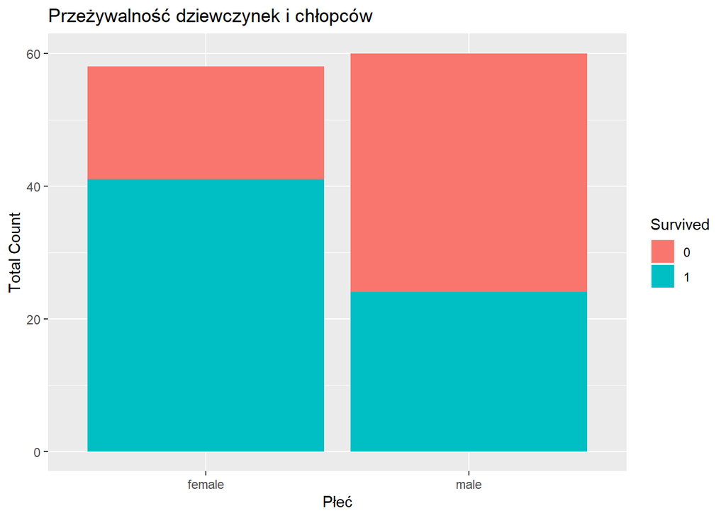

Przeżywalność dziewczynek jest nieznacznie niższa, niż przeżywalność kobiet. Przeżywalność chłopców jest zdecydowanie wyższa, niż przeżywalność mężczyzn.